# Importing necessary libraries

## Step 7: Analyze Target Variable Distribution and Class Imbalance

```python
# Get counts and percentages of target classes
target_counts = df['Target'].value_counts()
target_percent = df['Target'].value_counts(normalize=True) * 100

# Display Class distribution in Target variable
print("Class distribution in 'Target':\n")
display(pd.DataFrame({
    'Count': target_counts,
    'Percentage': target_percent.round(2)
}))
```

```
Class distribution in 'Target':
```

| Target | Count | Percentage |
| --- | --- | --- |
| graduate | 2209 | 49.93 |
| dropout | 1421 | 32.12 |
| enrolled | 794 | 17.95 |

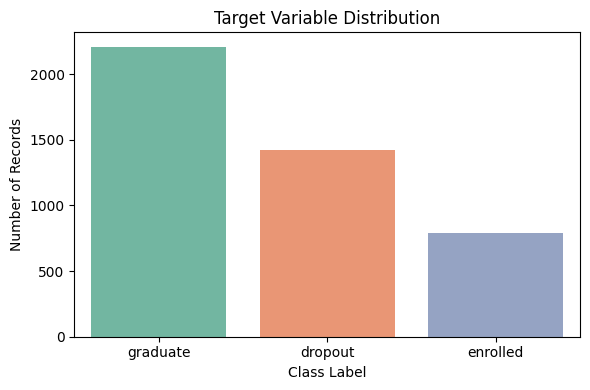

```python
# Plot class distribution
plt.figure(figsize=(6, 4))
sns.countplot(data=df, x='Target', order=target_counts.index, palette='Set2')
plt.title('Target Variable Distribution')
plt.ylabel('Number of Records')
plt.xlabel('Class Label')
plt.tight_layout()
plt.show()
```

### Observations:

- The target variable contains three classes: Graduate, Dropout, and Enrolled
- Class distribution:
  - Graduate: 2,209 instances (49.93%)
  - Dropout: 1,421 instances (32.12%)
  - Enrolled: 794 instances (17.95%)
- This indicates a moderate class imbalance with the Enrolled class being significantly underrepresented
- Such imbalance may affect model performance especially in metrics like accuracy
- Stratified sampling and appropriate evaluation metrics (e.g., F1-score, balanced accuracy) should be considered during model training and validation

## Step 8: Apply SMOTE for Class Balancing

```python
# Separate features and target
X = df.drop('Target', axis=1)
y = df['Target']

# Convert target variable to numerical format
y_encoded = y.map({'graduate': 0, 'dropout': 1, 'enrolled': 2})

# Split the data into train and test sets (80-20)
X_train, X_test, y_train, y_test = train_test_split(X, y_encoded, test_size=0.2, random_state=42, stratify=y_encoded)

# Apply one-hot encoding to categorical variables (if any)
X_train_encoded = pd.get_dummies(X_train)
X_test_encoded = pd.get_dummies(X_test)

# Align columns of test set with training (in case of missing categories)
X_test_encoded = X_test_encoded.reindex(columns=X_train_encoded.columns, fill_value=0)

# Apply SMOTE to training data only
smote = SMOTE(random_state=42)
X_train_balanced, y_train_balanced = smote.fit_resample(X_train_encoded, y_train)

# Format and display class distribution after SMOTE
smote_counts = pd.Series(y_train_balanced).value_counts().sort_index()
smote_percent = pd.Series(y_train_balanced).value_counts(normalize=True).sort_index() * 100

smote_labels = {0: 'Graduate', 1: 'Dropout', 2: 'Enrolled'}
smote_df = pd.DataFrame({
    'Count': smote_counts,
    'Percentage': smote_percent.round(2)
})
smote_df.index = smote_df.index.map(smote_labels)

# Display the new class distribution after SMOTE
print("Class distribution after applying SMOTE:\n")
display(smote_df)
```

```
Class distribution after applying SMOTE:
```

| Target | Count | Percentage |
| --- | --- | --- |
| Graduate | 1767 | 33.33 |
| Dropout | 1767 | 33.33 |
| Enrolled | 1767 | 33.33 |

# Phase 2: Feature Engineering and Dimensionality Reduction

```python
# Preprocessing – Encoding & Scaling

X = df.drop(columns=['Target'])
y = df['Target']

# Continuous features (verify that values are not constant or missing)
cont_features = [
    'Admission grade', 'Previous qualification (grade)',
    'Curricular units 1st sem (grade)', 'Curricular units 2nd sem (grade)',
    'Age at enrollment', 'Unemployment rate', 'Inflation rate', 'GDP'
]

for col in cont_features:
    if col not in X.columns or X[col].nunique() <= 1:
        raise ValueError(f"Column {col} is missing or not valid for scaling!")

# Apply standard scaling safely
scaler = StandardScaler()
X[cont_features] = scaler.fit_transform(X[cont_features])
print("Feature scaling complete.")
```

```
Feature scaling complete.
```

```python
X
```

|  | Marital status | Application mode | Application order | Course | Daytime/evening attendance | Previous qualification | Previous qualification (grade) | Nationality | Mother's qualification | Father's qualification | ... | Curricular units 1st sem (without evaluations) | Curricular units 2nd sem (credited) | Curricular units 2nd sem (enrolled) | Curricular units 2nd sem (evaluations) | Curricular units 2nd sem (approved) | Curricular units 2nd sem (grade) | Curricular units 2nd sem (without evaluations) | Unemployment rate | Inflation rate | GDP |
| --- | --- | --- | --- | --- | --- | --- | --- | --- | --- | --- | --- | --- | --- | --- | --- | --- | --- | --- | --- | --- | --- |
| 0 | 1 | 17 | 5 | 171 | 1 | 1 | -0.804841 | 1 | 19 | 12 | ... | 0 | 0 | 0 | 0 | 0 | -1.963489 | 0 | -0.287638 | 0.124386 | 0.765761 |
| 1 | 1 | 15 | 1 | 9254 | 1 | 1 | 2.076819 | 1 | 1 | 3 | ... | 0 | 0 | 6 | 6 | 6 | 0.659562 | 0 | 0.876222 | -1.105222 | 0.347199 |
| 2 | 1 | 1 | 5 | 9070 | 1 | 1 | -0.804841 | 1 | 37 | 37 | ... | 0 | 0 | 6 | 0 | 0 | -1.963489 | 0 | -0.287638 | 0.124386 | 0.765761 |
| 3 | 1 | 17 | 2 | 9773 | 1 | 1 | -0.804841 | 1 | 38 | 37 | ... | 0 | 0 | 6 | 10 | 5 | 0.416450 | 0 | -0.813253 | -1.466871 | -1.375511 |
| 4 | 2 | 39 | 1 | 8014 | 0 | 1 | -2.473171 | 1 | 37 | 38 | ... | 0 | 0 | 6 | 6 | 6 | 0.531608 | 0 | 0.876222 | -1.105222 | 0.347199 |
| ... | ... | ... | ... | ... | ... | ... | ... | ... | ... | ... | ... | ... | ... | ... | ... | ... | ... | ... | ... | ... | ... |
| 4419 | 1 | 1 | 6 | 9773 | 1 | 1 | -0.577342 | 1 | 1 | 1 | ... | 0 | 0 | 6 | 8 | 5 | 0.467631 | 0 | 1.476924 | 1.137005 | -1.789667 |
| 4420 | 1 | 1 | 2 | 9773 | 1 | 1 | -0.956508 | 105 | 1 | 1 | ... | 0 | 0 | 6 | 6 | 2 | 0.147747 | 0 | -0.175007 | -0.454253 | 0.889126 |
| 4421 | 1 | 1 | 1 | 9500 | 1 | 1 | 1.621820 | 1 | 37 | 37 | ... | 0 | 0 | 8 | 9 | 1 | 0.627573 | 0 | 0.876222 | -1.105222 | 0.347199 |
| 4422 | 1 | 1 | 1 | 9147 | 1 | 1 | 3.593483 | 1 | 37 | 37 | ... | 0 | 0 | 5 | 6 | 5 | 0.339678 | 0 | -0.813253 | -1.466871 | -1.375511 |
| 4423 | 1 | 10 | 1 | 9773 | 1 | 1 | 1.470154 | 22 | 38 | 37 | ... | 0 | 0 | 6 | 6 | 6 | 0.531608 | 0 | 0.425695 | 1.787974 | -0.749872 |

4424 rows × 36 columns

```python
# Dimensionality Reduction (PCA & RFE)

# Safe fallback: default to PCA
try:
    pca = PCA(n_components=0.95)
    X_pca = pca.fit_transform(X)
    print(f"PCA reduced to {X_pca.shape[1]} features")
except Exception as e:
    raise RuntimeError("PCA failed: " + str(e))

# RFE with Logistic Regression (alternative)
try:
    base_model = LogisticRegression(max_iter=1000)
    rfe = RFE(base_model, n_features_to_select=20)
    X_rfe = rfe.fit_transform(X, y)

    print("RFE selected 20 best features.")
except Exception as e:
    raise RuntimeError("RFE failed: " + str(e))

#Storing feature names
if hasattr(X, 'columns'):
    selected_features = X.columns[rfe.support_].tolist()
    print("Selected RFE feature names:")
    print(selected_features)
else:
    print("X is not a DataFrame — cannot get feature names directly.")

# Choose one version for modeling
X_model = X_rfe  # or X_pca
```

```
PCA reduced to 1 features
RFE selected 20 best features.
Selected RFE feature names:
['Admission grade', 'Displaced', 'Educational special needs', 'Debtor', 'Tuition fees up to date', 'Gender', 'Scholarship holder', 'Age at enrollment', 'International', 'Curricular units 1st sem (credited)', 'Curricular units 1st sem (enrolled)', 'Curricular units 1st sem (approved)', 'Curricular un…
```

MAPPNING FEATURES NUMBERS TO NAMES

```python
# Only if X is a DataFrame with column names
if hasattr(X, 'columns'):
    # Get boolean mask of selected features from RFE
    rfe_mask = rfe.support_

    # Get list of feature names selected by RFE
    selected_features = X.columns[rfe_mask].tolist()

    # Map RFE index positions (0 to 19) to original feature names
    feature_index_map = {i: name for i, name in enumerate(selected_features)}

    print("📌 RFE index-to-feature mapping:")
    print(feature_index_map)

    # Optional: just a list version if you don’t need mapping
    feature_name_list = selected_features  # List[str]
else:
    print("⚠️ X is not a DataFrame — cannot extract feature names.")
```

```
📌 RFE index-to-feature mapping:
{0: 'Admission grade', 1: 'Displaced', 2: 'Educational special needs', 3: 'Debtor', 4: 'Tuition fees up to date', 5: 'Gender', 6: 'Scholarship holder', 7: 'Age at enrollment', 8: 'International', 9: 'Curricular units 1st sem (credited)', 10: 'Curricular units 1st sem (enrolled)', 11: 'Curricular uni…
```

**PCA (Principal Component Analysis):**

Reduced to 1 feature: PCA transformed the original set of features into a single principal component. This suggests that most of the variance in the data is captured by one linear combination of the features. While this can be useful for dimensionality reduction, it may lose specific feature-level details which can be important in predictive modeling.

**RFE (Recursive Feature Elimination):**

Selected 20 features: RFE has identified the top 20 features that are most important for the model. By iteratively removing the least significant features, RFE ensures that the remaining features are the best predictors for the target variable.

**Selected RFE Feature Names:**

The chosen features span a mix of demographic, academic, and socio-economic factors, such as:

- Demographic: Gender, Age at enrollment, International status, Scholarship holder
- Academic performance: Curricular units from both the 1st and 2nd semesters, including credits, enrollment, approval, and grades
- Socio-economic factors: Admission grade, Tuition fees up to date, Debtor status, Unemployment rate
- Other factors: Displaced, Educational special needs

These features are likely to provide relevant and meaningful information for predicting the target variable. The presence of both academic and socio-economic features reflects the complexity of the data and the range of factors that may influence the outcome.

# Phase 3 : Model Building and Evaluation

```python
X_model = pd.DataFrame(X_model)

# Encode target
label_encoder = LabelEncoder()
y_encoded = label_encoder.fit_transform(y)

# Split
X_train, X_test, y_train, y_test = train_test_split(
    X_model, y_encoded, test_size=0.2, stratify=y_encoded, random_state=42
)

# DO NOT reindex here (since it's numeric)
# Apply SMOTE
smote = SMOTE(random_state=42)
X_train_balanced, y_train_balanced = smote.fit_resample(X_train, y_train)

# Logistic Regression

model_lr = LogisticRegression(max_iter=1000)
model_lr.fit(X_train_balanced, y_train_balanced)
y_pred_lr = model_lr.predict(X_test)

print("Logistic Regression Report")
print(classification_report(y_test, y_pred_lr, zero_division=0))

# Random Forest & XGBoost

# Encode string labels to numeric
label_encoder = LabelEncoder()
y_encoded = label_encoder.fit_transform(y)

# Re-split using encoded y
X_train, X_test, y_train, y_test = train_test_split(
    X_model, y_encoded, test_size=0.2, stratify=y_encoded, random_state=42
)

# Train Random Forest
model_rf = RandomForestClassifier(random_state=42)
model_rf.fit(X_train_balanced, y_train_balanced)
y_pred_rf = model_rf.predict(X_test)

# Train XGBoost
model_xgb = XGBClassifier(use_label_encoder=False, eval_metric='mlogloss')
model_xgb.fit(X_train_balanced, y_train_balanced)
y_pred_xgb = model_xgb.predict(X_test)

# Decode predictions for human-readable output
y_test_labels = label_encoder.inverse_transform(y_test)
y_pred_rf_labels = label_encoder.inverse_transform(y_pred_rf)
y_pred_xgb_labels = label_encoder.inverse_transform(y_pred_xgb)

# Print classification reports
print("Random Forest Report:\n", classification_report(y_test_labels, y_pred_rf_labels, zero_division=0))
print("XGBoost Report:\n", classification_report(y_test_labels, y_pred_xgb_labels, zero_division=0))
```

```
Logistic Regression Report
              precision    recall  f1-score   support

           0       0.86      0.69      0.76       284
           1       0.42      0.64      0.50       159
           2       0.86      0.80      0.83       442

    accuracy                           0.74       885
   macro avg       0.71      0.71      0.70       885
weighted avg       0.78      0.74      0.75       885

Random Forest Report:
               precision    recall  f1-score   support

     dropout       0.82      0.74      0.78       284
    enrolled       0.48      0.45      0.46       159
    graduate       0.81      0.88      0.84       442

    accuracy                           0.76       885
   macro avg       0.70      0.69      0.70       885
weighted avg       0.75      0.76      0.75       885

XGBoost Report:
               precision    recall  f1-score   support

     dropout       0.79      0.73      0.76       284
    enrolled       0.46      0.45      0.46       159
    graduate       0.82      0.87      0.85       442

    accuracy                           0.75       885
   macro avg       0.69      0.68      0.69       885
weighted avg       0.75      0.75      0.75       885
```

### Observations:

- The consistently lower precision, recall, and F1-score for the "enrolled" class across all three models—Logistic Regression, Random Forest, and XGBoost—indicates a challenge in accurately identifying this particular class. This may stem from class imbalance or overlapping feature distributions that make "enrolled" harder to distinguish from the "dropout" and "graduate" classes.
- In such scenarios:
  - Precision suffers due to a high number of false positives—many instances are incorrectly predicted as "enrolled".
  - Recall drops when the model fails to identify a significant portion of true "enrolled" cases.
  - F1-score, being the harmonic mean of precision and recall, captures this imbalance clearly and reflects the model's difficulty in handling this class.
- This indicates that while the overall accuracy may look acceptable, the model is not equally effective across all classes, and struggles particularly with the "enrolled" category.
- Random Forest shows the highest overall accuracy (76%) and offers the most balanced performance across all three classes. It performs particularly well for the "graduate" class and reasonably for "dropout", while still underperforming on "enrolled". Its strength lies in capturing non-linear feature interactions and handling noisy data, which helps improve general performance.
- Logistic Regression, with an accuracy of 74%, performs surprisingly well given its linear assumptions. It achieves the highest recall (0.64) for the "enrolled" class, meaning it identifies more actual "enrolled" cases compared to the other models, but its low precision (0.42) indicates many false positives. The model likely struggles due to its inability to capture non-linear patterns, especially when features overlap between classes.
- XGBoost, known for its ability to handle imbalanced datasets and learn complex relationships, achieves 75% accuracy but doesn’t significantly outperform the other models. The performance drop, especially for the "enrolled" class, suggests that the current model may be overfitting to majority classes or has suboptimal hyperparameters. With further tuning (e.g., adjusting learning rate, class weights, or regularization), XGBoost could potentially outperform the others.

[figure not shown]

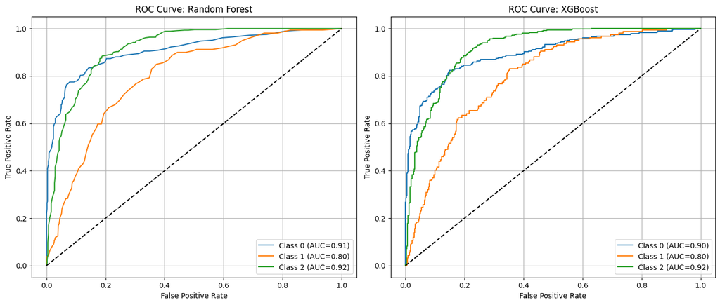

```python
# Store confusion matrices and ROC data
confusion_data = []
roc_data = []

# Collect both confusion matrix and ROC curve data
def xgboost_rf_evaluate_model(model, X, y, model_name):
    y_pred = model.predict(X)
    cm = confusion_matrix(y, y_pred)
    confusion_data.append((cm, model.classes_, model_name))

    # Multiclass ROC preparation
    if len(np.unique(y)) > 2:
        y_bin = label_binarize(y, classes=model.classes_)
        y_score = model.predict_proba(X)
        fpr, tpr, roc_auc = {}, {}, {}
        for i in range(len(model.classes_)):
            fpr[i], tpr[i], _ = roc_curve(y_bin[:, i], y_score[:, i])
            roc_auc[i] = auc(fpr[i], tpr[i])
        roc_data.append((model_name, fpr, tpr, roc_auc, model.classes_))
    else:
        y_score = model.predict_proba(X)[:, 1]
        fpr, tpr, _ = roc_curve(y, y_score)
        roc_auc_val = auc(fpr, tpr)
        roc_data.append((model_name, {0: fpr}, {0: tpr}, {0: roc_auc_val}, model.classes_))

# Evaluate both models
xgboost_rf_evaluate_model(model_rf, X_test, y_test, "Random Forest")
xgboost_rf_evaluate_model(model_xgb, X_test, y_test, "XGBoost")

# === Plot Confusion Matrices Side by Side ===
fig, axes = plt.subplots(1, 2, figsize=(12, 5))
for idx, (cm, labels, name) in enumerate(confusion_data):
    disp = ConfusionMatrixDisplay(confusion_matrix=cm, display_labels=labels)
    disp.plot(ax=axes[idx], cmap=plt.cm.Blues, colorbar=False)
    axes[idx].set_title(f"Confusion Matrix: {name}")
plt.tight_layout()
plt.show()

# === Plot ROC Curves Side by Side ===
fig, axes = plt.subplots(1, 2, figsize=(14, 6))
for idx, (model_name, fpr, tpr, roc_auc, classes) in enumerate(roc_data):
    ax = axes[idx]
    if len(classes) > 2:
        for i in range(len(classes)):
            ax.plot(fpr[i], tpr[i], label=f"Class {classes[i]} (AUC={roc_auc[i]:.2f})")
    else:
        ax.plot(fpr[0], tpr[0], label=f"AUC = {roc_auc[0]:.2f}")
    ax.plot([0, 1], [0, 1], 'k--')
    ax.set_title(f"ROC Curve: {model_name}")
    ax.set_xlabel("False Positive Rate")
    ax.set_ylabel("True Positive Rate")
    ax.legend(loc="lower right")
    ax.grid(True)
plt.tight_layout()
plt.show()
```

### Observations:

- Both Random Forest and XGBoost do a great job predicting Dropouts (Class 0) and Graduates (Class 2). They have high AUC scores (above 0.90) and very few mistakes for these classes.
- However, "Enrolled" (Class 1) is much harder for both models:
  - They make a lot of mistakes for this class (only around 60 correct predictions, many misclassified).
  - AUC scores for this class are lower (Random Forest: 0.80, XGBoost: 0.80), showing the models are less confident and accurate when predicting "Enrolled".

```python
# Cross Validation

for clf, name in zip([model_rf, model_xgb], ['Random Forest', 'XGBoost']):
    scores = cross_val_score(clf, X_model, y_encoded, cv=5, scoring='accuracy')
    print(f"{name} CV Accuracy: {scores.mean():.4f} ± {scores.std():.4f}")
```

```
Random Forest CV Accuracy: 0.7672 ± 0.0081
XGBoost CV Accuracy: 0.7599 ± 0.0118
```

```python
# Hyperparameter Tuning with GridSearchCV

# Random Forest Tuning
param_grid_rf = {
    'n_estimators': [100, 200],
    'max_depth': [10, 20, None],
    'min_samples_split': [2, 5]
}

grid_rf = GridSearchCV(RandomForestClassifier(random_state=42),
                       param_grid=param_grid_rf,
                       cv=3, scoring='f1_weighted', verbose=1, n_jobs=-1)
grid_rf.fit(X_train, y_train)

print("Best RF Params:", grid_rf.best_params_)
print("Tuned RF F1:", f1_score(y_test, grid_rf.predict(X_test), average='weighted'))

# XGBoost Tuning
param_grid_xgb = {
    'n_estimators': [100, 200],
    'max_depth': [3, 6, 10],
    'learning_rate': [0.01, 0.1],
}

grid_xgb = GridSearchCV(XGBClassifier(use_label_encoder=False, eval_metric='mlogloss'),
                        param_grid=param_grid_xgb,
                        cv=3, scoring='f1_weighted', verbose=1, n_jobs=-1)
grid_xgb.fit(X_train, y_train)

print("Best XGB Params:", grid_xgb.best_params_)
print("Tuned XGB F1:", f1_score(y_test, grid_xgb.predict(X_test), average='weighted'))
```

```
Fitting 3 folds for each of 12 candidates, totalling 36 fits
Best RF Params: {'max_depth': 20, 'min_samples_split': 2, 'n_estimators': 100}
Tuned RF F1: 0.7577519233510005
Fitting 3 folds for each of 12 candidates, totalling 36 fits
Best XGB Params: {'learning_rate': 0.1, 'max_depth': 3, 'n_estimators': 200}
Tuned XGB F1: 0.7530381234012914
```

# Phase 4: Finalization and Reporting

```python
# Final cleanup before model comparison
# Always work with encoded y values

# Reset label encoder mapping to ensure it matches numeric → label
y_encoded = label_encoder.fit_transform(df['Target'])
X_model = X_model  # already selected from PCA or RFE

# Re-split main dataset using encoded labels
X_train, X_test, y_train, y_test = train_test_split(
    X_model, y_encoded, test_size=0.2, stratify=y_encoded, random_state=42
)

# If SMOTE was used earlier, regenerate based on y_encoded
sm = SMOTE(random_state=42)
X_res, y_res = sm.fit_resample(X_model, y_encoded)
X_train_sm, X_test_sm, y_train_sm, y_test_sm = train_test_split(
    X_res, y_res, test_size=0.2, stratify=y_res, random_state=42
)

# FORCE labels to be NumPy arrays of integer type (no hidden strings)
y_test = np.array(y_test, dtype=int)
y_test_sm = np.array(y_test_sm, dtype=int)
```

```python
# Model Comparison Table

# 1. Re-encode entire target column fresh
label_encoder = LabelEncoder()
y_encoded = label_encoder.fit_transform(df['Target'])

# 2. Re-split dataset (for consistency)
X_train, X_test, y_train, y_test = train_test_split(
    X_model, y_encoded, test_size=0.2, stratify=y_encoded, random_state=42
)

# 3. Rebuild SMOTE version
sm = SMOTE(random_state=42)
X_res, y_res = sm.fit_resample(X_model, y_encoded)
X_train_sm, X_test_sm, y_train_sm, y_test_sm = train_test_split(
    X_res, y_res, test_size=0.2, stratify=y_res, random_state=42
)

# 4. Re-train all models from scratch on encoded labels
model_lr = LogisticRegression(max_iter=1000)
model_lr.fit(X_train, y_train)

model_rf = RandomForestClassifier(random_state=42)
model_rf.fit(X_train, y_train)

model_xgb = XGBClassifier(use_label_encoder=False, eval_metric='mlogloss')
model_xgb.fit(X_train, y_train)

model_rf_sm = RandomForestClassifier(random_state=42)
model_rf_sm.fit(X_train_sm, y_train_sm)

model_xgb_sm = XGBClassifier(use_label_encoder=False, eval_metric='mlogloss')
model_xgb_sm.fit(X_train_sm, y_train_sm)

# 5. Safe Model Comparison Block
results = []
model_variants = {
    "Logistic Regression": (model_lr, X_test, y_test),
    "Random Forest": (model_rf, X_test, y_test),
    "XGBoost": (model_xgb, X_test, y_test),
    "RF + SMOTE": (model_rf_sm, X_test_sm, y_test_sm),
    "XGB + SMOTE": (model_xgb_sm, X_test_sm, y_test_sm)
}

for name, (model, X_eval, y_eval) in model_variants.items():
    preds = model.predict(X_eval)

    # Guarantee integer format
    y_eval = np.array(y_eval, dtype=int)
    preds = np.array(preds, dtype=int)

    acc = accuracy_score(y_eval, preds)
    f1 = f1_score(y_eval, preds, average='weighted', zero_division=0)

    results.append([name, acc, f1])

df_results = pd.DataFrame(results, columns=['Model', 'Accuracy', 'F1-Score'])
print("Final Model Comparison Table:")
print(df_results)
```

```
Final Model Comparison Table:
                 Model  Accuracy  F1-Score
0  Logistic Regression  0.767232  0.752708
1        Random Forest  0.776271  0.764920
2              XGBoost  0.740113  0.733697
3           RF + SMOTE  0.831071  0.831032
4          XGB + SMOTE  0.815234  0.814868
```

### Overall Model Comparison

The classification task revealed that the "Enrolled" class is the most difficult to predict due to class imbalance and possibly overlapping features. All base models struggled with this class, showing low recall and F1-scores.

```python
# Clear containers
confusion_data = []
roc_data = []

models = [
    ("Logistic Regression", model_lr),
    ("Random Forest", model_rf),
    ("XGBoost", model_xgb),
    ("Tuned Random Forest", grid_rf.best_estimator_),
    ("Tuned XGBoost", grid_xgb.best_estimator_)
]

# Binary or multiclass
y_classes = np.unique(y_test)
is_multiclass = len(y_classes) > 2
y_test_bin = label_binarize(y_test, classes=y_classes) if is_multiclass else y_test

# Evaluate models
for name, model in models:
    print(f"\n=== Classification Report for {name} ===")
    y_pred = model.predict(X_test)
    print(classification_report(y_test, y_pred, digits=4))

    cm = confusion_matrix(y_test, y_pred)
    confusion_data.append((cm, y_classes, name))

    if is_multiclass:
        y_score = model.predict_proba(X_test)
        fpr, tpr, roc_auc = {}, {}, {}
        for i in range(len(y_classes)):
            fpr[i], tpr[i], _ = roc_curve(y_test_bin[:, i], y_score[:, i])
            roc_auc[i] = auc(fpr[i], tpr[i])
        roc_data.append((name, fpr, tpr, roc_auc, y_classes))
    else:
        y_score = model.predict_proba(X_test)[:, 1]
        fpr, tpr, _ = roc_curve(y_test, y_score)
        roc_auc_val = auc(fpr, tpr)
        roc_data.append((name, {0: fpr}, {0: tpr}, {0: roc_auc_val}, y_classes))
```

```
=== Classification Report for Logistic Regression ===
              precision    recall  f1-score   support

           0     0.8060    0.7606    0.7826       284
           1     0.5192    0.3396    0.4106       159
           2     0.7973    0.9253    0.8565       442

    accuracy                         0.7672       885
   macro avg     0.7075    0.6752    0.6833       885
weighted avg     0.7501    0.7672    0.7527       885


=== Classification Report for Random Forest ===
              precision    recall  f1-score   support

           0     0.8141    0.7711    0.7920       284
           1     0.5780    0.3962    0.4701       159
           2     0.7988    0.9163    0.8535       442

    accuracy                         0.7763       885
   macro avg     0.7303    0.6945    0.7052       885
weighted avg     0.7641    0.7763    0.7649       885


=== Classification Report for XGBoost ===
              precision    recall  f1-score   support

           0     0.7739    0.7113    0.7413       284
           1     0.4317    0.3774    0.4027       159
           2     0.8103    0.8891    0.8479       442

    accuracy                         0.7401       885
   macro avg     0.6720    0.6593    0.6640       885
weighted avg     0.7306    0.7401    0.7337       885


=== Classification Report for Tuned Random Forest ===
              precision    recall  f1-score   support

           0     0.8120    0.7606    0.7855       284
           1     0.5566    0.3711    0.4453       159
           2     0.7934    0.9208    0.8524       442

    accuracy                         0.7706       885
   macro avg     0.7207    0.6841    0.6944       885
weighted avg     0.7568    0.7706    0.7578       885


=== Classification Report for Tuned XGBoost ===
              precision    recall  f1-score   support

           0     0.7992    0.7430    0.7701       284
           1     0.5085    0.3774    0.4332       159
           2     0.8052    0.9163    0.8571       442

    accuracy                         0.7638       885
   macro avg     0.7043    0.6789    0.6868       885
weighted avg     0.7500    0.7638    0.7530       885
```

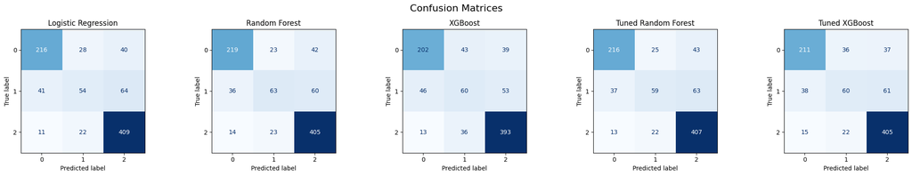

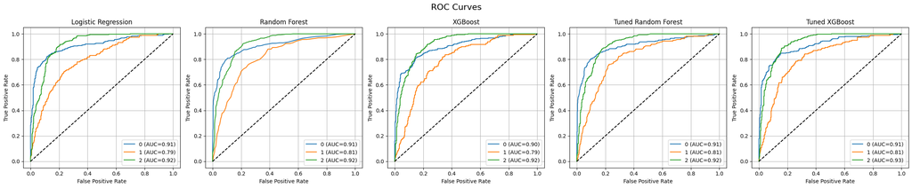

```python
# Clear containers
confusion_data = []
roc_data = []

models = [
    ("Logistic Regression", model_lr),
    ("Random Forest", model_rf),
    ("XGBoost", model_xgb),
    ("Tuned Random Forest", grid_rf.best_estimator_),
    ("Tuned XGBoost", grid_xgb.best_estimator_)
]

# Binary or multiclass
y_classes = np.unique(y_test)
is_multiclass = len(y_classes) > 2
y_test_bin = label_binarize(y_test, classes=y_classes) if is_multiclass else y_test

# Evaluate models
for name, model in models:
    y_pred = model.predict(X_test)
    cm = confusion_matrix(y_test, y_pred)
    confusion_data.append((cm, y_classes, name))

    if is_multiclass:
        y_score = model.predict_proba(X_test)
        fpr, tpr, roc_auc = {}, {}, {}
        for i in range(len(y_classes)):
            fpr[i], tpr[i], _ = roc_curve(y_test_bin[:, i], y_score[:, i])
            roc_auc[i] = auc(fpr[i], tpr[i])
        roc_data.append((name, fpr, tpr, roc_auc, y_classes))
    else:
        y_score = model.predict_proba(X_test)[:, 1]
        fpr, tpr, _ = roc_curve(y_test, y_score)
        roc_auc_val = auc(fpr, tpr)
        roc_data.append((name, {0: fpr}, {0: tpr}, {0: roc_auc_val}, y_classes))

# === Plot Confusion Matrices ===
fig, axes = plt.subplots(1, 5, figsize=(22, 4))
for idx, (cm, labels, name) in enumerate(confusion_data):
    disp = ConfusionMatrixDisplay(confusion_matrix=cm, display_labels=labels)
    disp.plot(ax=axes[idx], cmap=plt.cm.Blues, colorbar=False)
    axes[idx].set_title(f"{name}")
    axes[idx].grid(False)
plt.suptitle("Confusion Matrices", fontsize=16)
plt.tight_layout()
plt.show()

# === Plot ROC Curves ===
fig, axes = plt.subplots(1, 5, figsize=(24, 5))
for idx, (name, fpr, tpr, roc_auc, classes) in enumerate(roc_data):
    ax = axes[idx]
    if len(classes) > 2:
        for i in range(len(classes)):
            ax.plot(fpr[i], tpr[i], label=f"{classes[i]} (AUC={roc_auc[i]:.2f})")
    else:
        ax.plot(fpr[0], tpr[0], label=f"AUC = {roc_auc[0]:.2f}")
    ax.plot([0, 1], [0, 1], 'k--')
    ax.set_title(f"{name}")
    ax.set_xlabel("False Positive Rate")
    ax.set_ylabel("True Positive Rate")
    ax.legend(loc="lower right")
    ax.grid(True)
plt.suptitle("ROC Curves", fontsize=16)
plt.tight_layout()
plt.show()
```

### Observations

```
📊 SHAP Beeswarm for Class 0
```

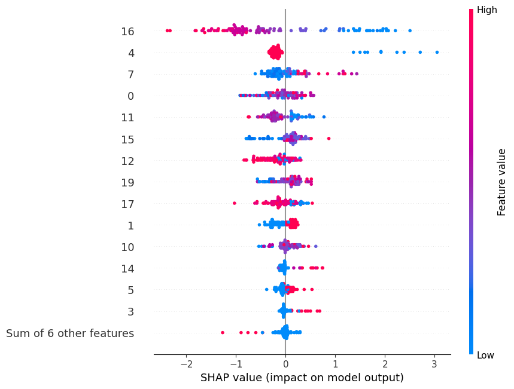

```
📊 SHAP Beeswarm for Class 1
```

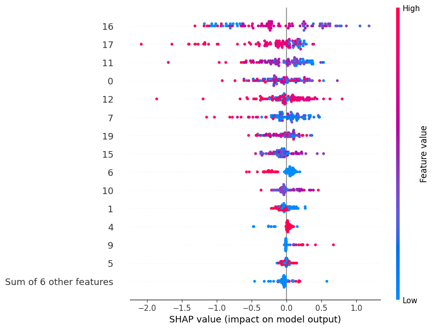

```
📊 SHAP Beeswarm for Class 2
```

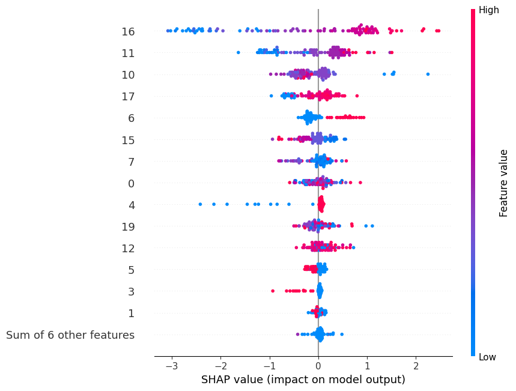

```python
# Use the new SHAP Explainer (wraps TreeExplainer under the hood)
explainer = shap.Explainer(model_xgb)

# Select 100 rows for performance
X_sample = X_test.sample(n=100, random_state=42)

# Explain predictions
shap_values = explainer(X_sample)  # shap.Explanation object

# Loop over classes
num_classes = shap_values.values.shape[2]
for class_index in range(num_classes):
    print(f"\n📊 SHAP Beeswarm for Class {class_index}")
    shap.plots.beeswarm(shap_values[:, :, class_index], max_display=15)
```

```python
print(f"SHAP shape: {shap_values[0].shape}")
print(f"X_sample shape: {X_sample.shape}")
```

```
SHAP shape: (20, 3)
X_sample shape: (100, 20)
```

### Observations

**Top Influential Feature Across All Classes:**

- Curricular units 2nd sem (approved) — strong indicator of academic success.

**Class 2:**

- High approval/enrollment in both semesters increases likelihood.
- Academic performance is a key driver.
- Scholarships have a mild positive effect.

**Class 1:**

- Strongly influenced by grades and admission performance.
- Scholarship and unemployment rate have a slight impact.

**General Insight:**

- Academic metrics (grades, approvals, enrollments) are far more impactful than demographics (gender, debtor, displaced).

```python
X_test
```

|  | 0 | 1 | 2 | 3 | 4 | 5 | 6 | 7 | 8 | 9 | 10 | 11 | 12 | 13 | 14 | 15 | 16 | 17 | 18 | 19 |
| --- | --- | --- | --- | --- | --- | --- | --- | --- | --- | --- | --- | --- | --- | --- | --- | --- | --- | --- | --- | --- |
| 1853 | 2.280459 | 1.0 | 0.0 | 0.0 | 1.0 | 1.0 | 0.0 | -0.430363 | 0.0 | 0.0 | 6.0 | 6.0 | 0.693599 | 0.0 | 0.0 | 6.0 | 6.0 | 0.851492 | 0.0 | 0.313064 |
| 2399 | -0.046830 | 0.0 | 0.0 | 0.0 | 1.0 | 1.0 | 0.0 | -0.562168 | 0.0 | 0.0 | 7.0 | 7.0 | 0.382406 | 0.0 | 0.0 | 8.0 | 8.0 | 0.284497 | 0.0 | 1.739731 |
| 510 | -0.433561 | 1.0 | 0.0 | 0.0 | 1.0 | 0.0 | 0.0 | -0.693973 | 0.0 | 0.0 | 6.0 | 4.0 | 0.022543 | 0.0 | 0.0 | 6.0 | 0.0 | -1.963489 | 0.0 | -0.813253 |
| 242 | -0.544055 | 1.0 | 0.0 | 0.0 | 1.0 | 0.0 | 1.0 | -0.430363 | 0.0 | 0.0 | 5.0 | 5.0 | 0.198050 | 0.0 | 0.0 | 5.0 | 5.0 | 0.646766 | 0.0 | 0.313064 |
| 3392 | 1.935164 | 0.0 | 0.0 | 0.0 | 1.0 | 0.0 | 1.0 | -0.298558 | 0.0 | 0.0 | 6.0 | 5.0 | 0.487120 | 0.0 | 0.0 | 6.0 | 6.0 | 0.467631 | 0.0 | 1.739731 |
| ... | ... | ... | ... | ... | ... | ... | ... | ... | ... | ... | ... | ... | ... | ... | ... | ... | ... | ... | ... | ... |
| 555 | 1.589869 | 0.0 | 0.0 | 0.0 | 1.0 | 1.0 | 0.0 | 0.228663 | 0.0 | 9.0 | 14.0 | 14.0 | 0.369132 | 0.0 | 3.0 | 9.0 | 6.0 | 0.120328 | 0.0 | 1.476924 |
| 2418 | 0.208688 | 1.0 | 0.0 | 0.0 | 0.0 | 1.0 | 1.0 | -0.166753 | 0.0 | 5.0 | 12.0 | 11.0 | 0.393266 | 0.0 | 4.0 | 11.0 | 11.0 | 0.467631 | 0.0 | -1.000972 |
| 2367 | 0.084382 | 1.0 | 0.0 | 0.0 | 1.0 | 1.0 | 0.0 | -0.693973 | 0.0 | 0.0 | 6.0 | 6.0 | 0.693599 | 0.0 | 0.0 | 6.0 | 6.0 | 0.659562 | 0.0 | 0.313064 |
| 1801 | 0.208688 | 0.0 | 0.0 | 0.0 | 1.0 | 1.0 | 0.0 | 1.019494 | 0.0 | 8.0 | 12.0 | 12.0 | 0.349468 | 0.0 | 6.0 | 10.0 | 7.0 | 0.586445 | 2.0 | -1.489043 |
| 4392 | 0.788784 | 0.0 | 0.0 | 0.0 | 1.0 | 0.0 | 0.0 | -0.693973 | 0.0 | 0.0 | 5.0 | 4.0 | 0.125782 | 0.0 | 0.0 | 5.0 | 5.0 | 0.147747 | 0.0 | -0.287638 |

885 rows × 20 columns

# Approach 2

# Phase 1: Data Understanding and Preprocessing

## Step 1: Load the Dataset

```python
# Load the dataset
file_id = '10SesEJia8bZH4LuNjVwr5B1kX2x_iGYK'
dataset_url = f'https://drive.google.com/uc?id={file_id}'
df = pd.read_csv(dataset_url, sep=';')
```

## Step 2: Standardize Dataset

```python
# 1. Clean column names: remove leading/trailing whitespace
df.columns = df.columns.str.strip()

# 2. Rename known incorrect or inconsistent column names
df.rename(columns={
    'Nacionality': 'Nationality',
    'Daytime/evening attendance\t': 'Daytime/evening attendance'
}, inplace=True)

# 3. Standardize string values in 'Target' column
df['Target'] = df['Target'].str.strip().str.lower()

df.head()
```

|  | Marital status | Application mode | Application order | Course | Daytime/evening attendance | Previous qualification | Previous qualification (grade) | Nationality | Mother's qualification | Father's qualification | ... | Curricular units 2nd sem (credited) | Curricular units 2nd sem (enrolled) | Curricular units 2nd sem (evaluations) | Curricular units 2nd sem (approved) | Curricular units 2nd sem (grade) | Curricular units 2nd sem (without evaluations) | Unemployment rate | Inflation rate | GDP | Target |
| --- | --- | --- | --- | --- | --- | --- | --- | --- | --- | --- | --- | --- | --- | --- | --- | --- | --- | --- | --- | --- | --- |
| 0 | 1 | 17 | 5 | 171 | 1 | 1 | 122.0 | 1 | 19 | 12 | ... | 0 | 0 | 0 | 0 | 0.000000 | 0 | 10.8 | 1.4 | 1.74 | dropout |
| 1 | 1 | 15 | 1 | 9254 | 1 | 1 | 160.0 | 1 | 1 | 3 | ... | 0 | 6 | 6 | 6 | 13.666667 | 0 | 13.9 | -0.3 | 0.79 | graduate |
| 2 | 1 | 1 | 5 | 9070 | 1 | 1 | 122.0 | 1 | 37 | 37 | ... | 0 | 6 | 0 | 0 | 0.000000 | 0 | 10.8 | 1.4 | 1.74 | dropout |
| 3 | 1 | 17 | 2 | 9773 | 1 | 1 | 122.0 | 1 | 38 | 37 | ... | 0 | 6 | 10 | 5 | 12.400000 | 0 | 9.4 | -0.8 | -3.12 | graduate |
| 4 | 2 | 39 | 1 | 8014 | 0 | 1 | 100.0 | 1 | 37 | 38 | ... | 0 | 6 | 6 | 6 | 13.000000 | 0 | 13.9 | -0.3 | 0.79 | graduate |

5 rows × 37 columns

```python
df.columns
```

```
Index(['Marital status', 'Application mode', 'Application order', 'Course',
       'Daytime/evening attendance', 'Previous qualification',
       'Previous qualification (grade)', 'Nationality',
       'Mother's qualification', 'Father's qualification',
       'Mother's occupation', 'Father's occupation', 'Admission grade',
       'Displaced', 'Educational special needs', 'Debtor',
       'Tuition fees up to date', 'Gender', 'Scholarship holder',
       'Age at enrollment', 'International',
       'Curricular units 1st sem (credited)',
       'Curricular units 1st sem (enrolled)',
       'Curricular units 1st sem (evaluations)',
       'Curricular units 1st sem (approved)',
       'Curricular units 1st sem (grade)',
       'Curricular units 1st sem (without evaluations)',
       'Curricular units 2nd sem (credited)',
       'Curricular units 2nd sem (enrolled)',
       'Curricular units 2nd sem (evaluations)',
       'Curricular units 2nd sem (approved)',
       'Curricular units 2nd sem (grade)',
       'Curricular units 2nd sem (without evaluations)', 'Unemployment rate',
       'Inflation rate', 'GDP', 'Target'],
      dtype='object')
```

```python
# Specifying the categorical variables
# Set target column
target_col = 'Target'  # Replace with your actual target column

# Define categorical features that need one-hot encoding
categorical_cols = [
    'Marital status', 'Application mode', 'Course', 'Daytime/evening attendance',
    'Previous qualification', 'Nationality', "Mother's qualification",
    "Father's qualification", "Mother's occupation", "Father's occupation", 'Gender'
]
```

## Step 3: Applying One-Hot Encoding

```python
X = df.drop(columns=['Target'])
y = df['Target']
```

```python
# One-Hot Encoding for categorical features
X_encoded = pd.get_dummies(X, columns=categorical_cols, drop_first=True)

# Identify numeric columns (after encoding, still in X, not X_encoded)
numeric_cols = X.select_dtypes(include=['int64', 'float64']).columns.tolist()
numeric_cols = [col for col in numeric_cols if col in X_encoded.columns]

# Scale numeric features
scaler = StandardScaler()
X_encoded[numeric_cols] = scaler.fit_transform(X_encoded[numeric_cols])

# Train-Test Split
X_train, X_test, y_train, y_test = train_test_split(X_encoded, y, test_size=0.2, random_state=42, stratify=y)

# Apply SMOTE to balance the classes
sm = SMOTE(random_state=42)
X_train_res, y_train_res = sm.fit_resample(X_train, y_train)
```

```python
# ENCODING LABELS
label_encoder = LabelEncoder()
y_encoded = label_encoder.fit_transform(y)
```

## Step 4: Apply SMOTE for Class Balancing

```python
# Apply SMOTE to handle class imbalance by generating synthetic samples for the minority class
# This helps improve model performance on imbalanced classification problems

sm = SMOTE(random_state=42)
X_res, y_res = sm.fit_resample(X_encoded, y_encoded)
```

# Phase 2: Feature Engineering and Dimensionality Reduction

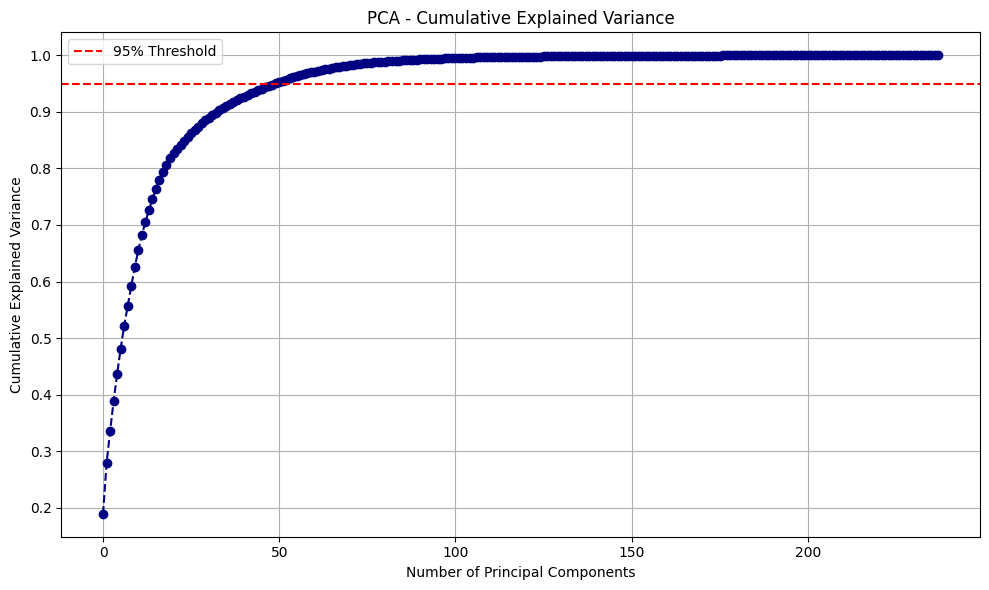

```python
# Fit PCA separately just to plot explained variance (retain all components)
pca_full = PCA().fit(X_res)

# Plot cumulative explained variance
plt.figure(figsize=(10, 6))
plt.plot(np.cumsum(pca_full.explained_variance_ratio_), marker='o', linestyle='--', color='navy')
plt.xlabel('Number of Principal Components')
plt.ylabel('Cumulative Explained Variance')
plt.title('PCA - Cumulative Explained Variance')
plt.grid(True)
plt.axhline(y=0.95, color='r', linestyle='--', label='95% Threshold')
plt.legend()
plt.tight_layout()
plt.show()
```

### Observations:

- Rapid Initial Growth:
  - The curve exhibits a sharp ascent at the outset, signifying that the initial principal components account for the majority of the variance present in the dataset. For instance, approximately the first 20 to 30 components are responsible for explaining over 80% of the variance.
- Quick Attainment of 95% Threshold:
  - The red dashed line at 0.95 (95%) represents a widely accepted benchmark for dimensionality reduction. According to the graph, around 50 principal components are adequate to capture 95% of the overall variance.
- Diminishing Returns:
  - After reaching about 100 components, the curve levels off, indicating that any additional components provide minimal new information.
  - Incorporating more components beyond this threshold results in only slight improvements in explained variance while increasing the complexity of the model.
- Implications for Use Cases:
  - Significant dimensionality reduction is achievable (for example, from over 200 features to approximately 50) while retaining most of the variance in the dataset. This approach aids in decreasing computational demands and may enhance model generalization without substantial loss of information.

```python
# Step 1: Fit PCA on full SMOTE data (X_res)
pca_full = PCA().fit(X_res)

# Step 2: Calculate cumulative explained variance
explained_var = np.cumsum(pca_full.explained_variance_ratio_)

# Step 3: Get number of components that explain 95% variance
n_components_95 = np.argmax(explained_var >= 0.95) + 1
print(f"Number of components to retain 95% variance: {n_components_95}")

# Step 4: Apply PCA using only those components
pca = PCA(n_components=n_components_95, random_state=42)
X_pca = pca.fit_transform(X_res)

# Step 5: Train-test split using reduced data
X_train, X_test, y_train, y_test = train_test_split(
    X_pca, y_res, test_size=0.2, stratify=y_res, random_state=42
)
print("Train/Test split complete. Train shape:", X_train.shape)
```

```
Number of components to retain 95% variance: 50
Train/Test split complete. Train shape: (5301, 50)
```

# Phase 3 : Model Building and Evaluation

#### LOGISIC REGRESSION

```python
# Initialize Logistic Regression model with a higher max_iter to ensure convergence
model_lr = LogisticRegression(max_iter=1000, random_state=42)
model_lr.fit(X_train, y_train)
y_pred_lr = model_lr.predict(X_test)
```

#### RANDOM FOREST

```python
# Initialize a Random Forest Classifier with a fixed random state for reproducibility
model_rf = RandomForestClassifier(random_state=42)
model_rf.fit(X_train, y_train)
y_pred_rf = model_rf.predict(X_test)
```

#### XGBoost

```python
# Initialize an XGBoost Classifier
# - use_label_encoder=False avoids warning for deprecated label encoding
# - eval_metric='mlogloss' sets the evaluation metric to log loss (suitable for classification)

model_xgb = XGBClassifier(use_label_encoder=False, eval_metric='mlogloss', random_state=42)
model_xgb.fit(X_train, y_train)
y_pred_xgb = model_xgb.predict(X_test)
```

#### DECODING PREDICTIONS FOR REPORTING

```python
# Inverse transform the encoded labels back to their original class names for better readability in reports
y_test_labels = label_encoder.inverse_transform(y_test)
y_pred_rf_labels = label_encoder.inverse_transform(y_pred_rf)
y_pred_xgb_labels = label_encoder.inverse_transform(y_pred_xgb)

# Print Classification Reports
print("Logistic Regression Report")
print(classification_report(
    label_encoder.inverse_transform(y_test),
    label_encoder.inverse_transform(y_pred_lr),
    zero_division=0
))
print("Random Forest Report:\n", classification_report(y_test_labels, y_pred_rf_labels, zero_division=0))
print("XGBoost Report:\n", classification_report(y_test_labels, y_pred_xgb_labels, zero_division=0))
```

```
Logistic Regression Report
              precision    recall  f1-score   support

     dropout       0.81      0.72      0.76       442
    enrolled       0.72      0.71      0.71       442
    graduate       0.77      0.87      0.82       442

    accuracy                           0.77      1326
   macro avg       0.77      0.77      0.77      1326
weighted avg       0.77      0.77      0.77      1326

Random Forest Report:
               precision    recall  f1-score   support

     dropout       0.85      0.81      0.83       442
    enrolled       0.79      0.83      0.81       442
    graduate       0.82      0.83      0.82       442

    accuracy                           0.82      1326
   macro avg       0.82      0.82      0.82      1326
weighted avg       0.82      0.82      0.82      1326

XGBoost Report:
               precision    recall  f1-score   support

     dropout       0.88      0.80      0.84       442
    enrolled       0.80      0.81      0.80       442
    graduate       0.81      0.87      0.84       442

    accuracy                           0.83      1326
   macro avg       0.83      0.83      0.83      1326
weighted avg       0.83      0.83      0.83      1326
```

### Updated Observations Based on the Classification Report:

#### Logistic Regression (Accuracy: 0.77)

- Performs reasonably well, especially for the **"graduate"** class (`precision=0.77`, `recall=0.87`, `f1=0.82`), indicating it's better at correctly identifying graduates.
- Struggles most with the **"enrolled"** class (`precision=0.72`, `recall=0.71`, `f1=0.71`), possibly due to overlapping features with other classes.
- Serves as a strong linear baseline, but lacks power in capturing complex or nonlinear class boundaries.

#### Random Forest (Accuracy: 0.82)

- Shows consistent improvements across all classes compared to Logistic Regression.
- Notably better at identifying **"dropout"** (`precision=0.85`, `recall=0.81`, `f1=0.83`) and **"enrolled"** (`precision=0.79`, `recall=0.83`, `f1=0.81`).
- The macro average and weighted average F1-scores are both 0.82, indicating robust performance across the board.

#### XGBoost (Accuracy: 0.83)

- Slightly outperforms Random Forest in overall performance.
- Best at identifying **"dropout"** (`precision=0.88`, `f1=0.84`) and **"graduate"** (`recall=0.87`, `f1=0.84`), showing strong generalization and reduced false negatives.
- The **"enrolled"** class shows modest improvement (`precision=0.80`, `recall=0.81`, `f1=0.80`), but still remains the most challenging.

### Key Insights:

- Progressing from Logistic Regression to Random Forest and then to XGBoost improves the overall weighted F1-score from 0.77 to 0.82 and finally to 0.83.
- The "dropout" class benefits the most from ensemble models, with recall increasing from 0.72 (Logistic Regression) to 0.81 (Random Forest) and remaining at 0.80 (XGBoost).
- The "enrolled" class remains the most difficult to predict accurately, suggesting the need for further feature engineering or more representative data.

```python
# Lists to store confusion matrix and ROC curve data for each model
confusion_data = []
roc_data = []

# Evaluate & collect CM + ROC
def evaluate_model(model, X, y, model_name):
    y_pred = model.predict(X)
    cm = confusion_matrix(y, y_pred)
    confusion_data.append((cm, model.classes_, model_name))

    if hasattr(model, "predict_proba"):
        if len(np.unique(y)) > 2:
            y_bin = label_binarize(y, classes=model.classes_)
            y_score = model.predict_proba(X)
            fpr, tpr, roc_auc = {}, {}, {}
            for i in range(len(model.classes_)):
                fpr[i], tpr[i], _ = roc_curve(y_bin[:, i], y_score[:, i])
                roc_auc[i] = auc(fpr[i], tpr[i])
            roc_data.append((model_name, fpr, tpr, roc_auc, model.classes_))
        else:
            y_score = model.predict_proba(X)[:, 1]
            fpr, tpr, _ = roc_curve(y, y_score)
            roc_auc_val = auc(fpr, tpr)
            roc_data.append((model_name, {0: fpr}, {0: tpr}, {0: roc_auc_val}, model.classes_))

# === Add all three models
evaluate_model(model_lr, X_test, y_test, "Logistic Regression")
evaluate_model(model_rf, X_test, y_test, "Random Forest")
evaluate_model(model_xgb, X_test, y_test, "XGBoost")
```

```python
def xgboost_rf_evaluate_model(model, X_test, y_test, model_name="Model"):
    print(f"=== {model_name} Evaluation ===")
    y_pred = model.predict(X_test)

    print("Accuracy:", accuracy_score(y_test, y_pred))
    print("Confusion Matrix:\n", confusion_matrix(y_test, y_pred))
    print("Classification Report:\n", classification_report(y_test, y_pred, zero_division=0))
    print("\n" + "="*40 + "\n")
```

#### GridSearchCV - Random Forest

```python
param_grid_rf = {
    'n_estimators': [100, 200],
    'max_depth': [10, 20, None],
    'min_samples_split': [2, 5]
}
grid_rf = GridSearchCV(RandomForestClassifier(random_state=42),
                       param_grid=param_grid_rf,
                       cv=3, scoring='f1_weighted', verbose=1, n_jobs=-1)
grid_rf.fit(X_train, y_train)
print("Best RF Params:", grid_rf.best_params_)
print("Tuned RF F1:", f1_score(y_test, grid_rf.predict(X_test), average='weighted'))
evaluate_model(grid_rf, X_test, y_test, "Random Forest (GridSearch)")
```

```
Fitting 3 folds for each of 12 candidates, totalling 36 fits
Best RF Params: {'max_depth': None, 'min_samples_split': 2, 'n_estimators': 200}
Tuned RF F1: 0.8220516864824741
```

#### GridSearchCV - XGBoost

```python
param_grid_xgb = {
    'n_estimators': [100, 200],
    'max_depth': [3, 6, 10],
    'learning_rate': [0.01, 0.1],
}
grid_xgb = GridSearchCV(XGBClassifier(use_label_encoder=False, eval_metric='mlogloss'),
                        param_grid=param_grid_xgb,
                        cv=3, scoring='f1_weighted', verbose=1, n_jobs=-1)
grid_xgb.fit(X_train, y_train)
print("Best XGB Params:", grid_xgb.best_params_)
print("Tuned XGB F1:", f1_score(y_test, grid_xgb.predict(X_test), average='weighted'))
evaluate_model(grid_xgb, X_test, y_test, "XGBoost (GridSearch)")
```

```
Fitting 3 folds for each of 12 candidates, totalling 36 fits
Best XGB Params: {'learning_rate': 0.1, 'max_depth': 10, 'n_estimators': 200}
Tuned XGB F1: 0.8355888841389184
```

### Observations:

- XGBoost demonstrates a superior performance compared to Random Forest, achieving an F1-score of 0.836 against 0.822. This observation supports the widely held belief that XGBoost often yields better outcomes due to its boosting algorithm, which enhances model accuracy incrementally.
- The process of hyperparameter tuning has positively impacted both models, resulting in improved F1-scores relative to their original configurations.
- The observed performance differences indicate that XGBoost is more adept at addressing this specific problem, although both models exhibit strong performance, with XGBoost emerging as the more polished choice following tuning.
- In summary, while both models are effectively optimized, XGBoost provides a marginal advantage in F1-score. For those seeking further enhancements, exploring additional hyperparameter optimization or ensembling techniques may be beneficial.

# Phase 4: Finalization and Reporting

```python
# Decode labels once for all
y_test_decoded = label_encoder.inverse_transform(y_test)

# Logistic Regression
y_pred_lr = model_lr.predict(X_test)
print("Logistic Regression Report")
print(classification_report(
    y_test_decoded,
    label_encoder.inverse_transform(y_pred_lr),
    zero_division=0
))

# Random Forest
y_pred_rf = model_rf.predict(X_test)
print("Random Forest Report")
print(classification_report(
    y_test_decoded,
    label_encoder.inverse_transform(y_pred_rf),
    zero_division=0
))

# XGBoost
y_pred_xgb = model_xgb.predict(X_test)
print("XGBoost Report")
print(classification_report(
    y_test_decoded,
    label_encoder.inverse_transform(y_pred_xgb),
    zero_division=0
))

# Tuned Random Forest (GridSearch)
y_pred_rf_grid = grid_rf.predict(X_test)
print("Random Forest (GridSearchCV) Report")
print(classification_report(
    y_test_decoded,
    label_encoder.inverse_transform(y_pred_rf_grid),
    zero_division=0
))

# === Tuned XGBoost (GridSearch)
y_pred_xgb_grid = grid_xgb.predict(X_test)
print("XGBoost (GridSearchCV) Report")
print(classification_report(
    y_test_decoded,
    label_encoder.inverse_transform(y_pred_xgb_grid),
    zero_division=0
))
```

```
Logistic Regression Report
              precision    recall  f1-score   support

     dropout       0.81      0.72      0.76       442
    enrolled       0.72      0.71      0.71       442
    graduate       0.77      0.87      0.82       442

    accuracy                           0.77      1326
   macro avg       0.77      0.77      0.77      1326
weighted avg       0.77      0.77      0.77      1326

Random Forest Report
              precision    recall  f1-score   support

     dropout       0.85      0.81      0.83       442
    enrolled       0.79      0.83      0.81       442
    graduate       0.82      0.83      0.82       442

    accuracy                           0.82      1326
   macro avg       0.82      0.82      0.82      1326
weighted avg       0.82      0.82      0.82      1326

XGBoost Report
              precision    recall  f1-score   support

     dropout       0.88      0.80      0.84       442
    enrolled       0.80      0.81      0.80       442
    graduate       0.81      0.87      0.84       442

    accuracy                           0.83      1326
   macro avg       0.83      0.83      0.83      1326
weighted avg       0.83      0.83      0.83      1326

Random Forest (GridSearchCV) Report
              precision    recall  f1-score   support

     dropout       0.86      0.79      0.82       442
    enrolled       0.79      0.83      0.81       442
    graduate       0.82      0.85      0.83       442

    accuracy                           0.82      1326
   macro avg       0.82      0.82      0.82      1326
weighted avg       0.82      0.82      0.82      1326

XGBoost (GridSearchCV) Report
              precision    recall  f1-score   support

     dropout       0.87      0.81      0.84       442
    enrolled       0.81      0.82      0.82       442
    graduate       0.83      0.87      0.85       442

    accuracy                           0.84      1326
   macro avg       0.84      0.84      0.84      1326
weighted avg       0.84      0.84      0.84      1326
```

### Model Summary Table

| Model | Accuracy | Key Strength |
| --- | --- | --- |
| Logistic Regression | 0.77 | High graduate recall, but overall less powerful |
| Random Forest | 0.82 | Good balance, improved overall over LR |
| XGBoost | 0.83 | Great dropout precision, best raw model |
| Random Forest (Tuned) | 0.82 | Consistent and balanced but similar to default |
| XGBoost (Tuned) | 0.84 | Top performance, most balanced and refined |

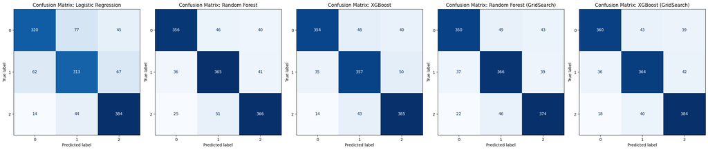

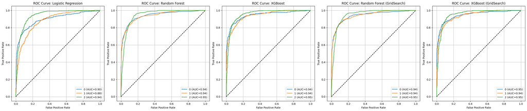

```python
# Confusion Matrices
fig, axes = plt.subplots(1, 5, figsize=(25, 5))
for idx, (cm, labels, name) in enumerate(confusion_data):
    disp = ConfusionMatrixDisplay(confusion_matrix=cm, display_labels=labels)
    disp.plot(ax=axes[idx], cmap=plt.cm.Blues, colorbar=False)
    axes[idx].set_title(f"Confusion Matrix: {name}")
plt.tight_layout()
plt.show()

# ROC Curves
fig, axes = plt.subplots(1, 5, figsize=(28, 6))
for idx, (model_name, fpr, tpr, roc_auc, classes) in enumerate(roc_data):
    ax = axes[idx]
    if len(classes) > 2:
        for i in range(len(classes)):
            ax.plot(fpr[i], tpr[i], label=f"{classes[i]} (AUC={roc_auc[i]:.2f})")
    else:
        ax.plot(fpr[0], tpr[0], label=f"AUC = {roc_auc[0]:.2f}")
    ax.plot([0, 1], [0, 1], 'k--')
    ax.set_title(f"ROC Curve: {model_name}")
    ax.set_xlabel("False Positive Rate")
    ax.set_ylabel("True Positive Rate")
    ax.legend(loc="lower right")
    ax.grid(True)
plt.tight_layout()
plt.show()
```

## ✅ Classification Report Comparison: Without vs With One-Hot Encoding (All Models)

The table below compares **F1-scores** and **accuracy** before and after applying **One-Hot Encoding**, with additional model tuning using **GridSearchCV**.

### F1-Score by Class

| Model | One-Hot | Dropout | Enrolled | Graduate | Accuracy | Macro Avg | Weighted Avg |
| --- | --- | --- | --- | --- | --- | --- | --- |
| Logistic Regression | ❌ No | 0.78 | 0.41 | 0.86 | 0.77 | 0.68 | 0.75 |
| Logistic Regression | ✅ Yes | 0.76 | 0.71 | 0.82 | 0.77 | 0.77 | 0.77 |
| Random Forest | ❌ No | 0.79 | 0.47 | 0.85 | 0.78 | 0.71 | 0.76 |
| Random Forest | ✅ Yes | 0.83 | 0.81 | 0.82 | 0.82 | 0.82 | 0.82 |
| Random Forest (GridSearchCV) | ✅ Yes | 0.82 | 0.81 | 0.83 | 0.82 | 0.82 | 0.82 |
| XGBoost | ❌ No | 0.74 | 0.40 | 0.85 | 0.74 | 0.66 | 0.73 |
| XGBoost | ✅ Yes | 0.84 | 0.80 | 0.84 | 0.83 | 0.83 | 0.83 |
| XGBoost (GridSearchCV) | ✅ Yes | 0.84 | 0.82 | 0.85 | 0.84 | 0.84 | 0.84 |

### Key Takeaways

- **XGBoost (GridSearchCV)** delivers the **best overall performance**:
  - Highest **Accuracy**: **0.84**
  - Strongest **F1-scores across all classes**, especially **“enrolled”** at **0.82**
  - Highest **Macro Avg and Weighted Avg**: **0.84**
- **Random Forest (GridSearchCV)** is also highly competitive and stable, ideal for faster tuning and interpretability.
- The **"Enrolled" class** improved the most after One-Hot Encoding and SMOTE:
  - F1-score jumped from **~0.40** to **~0.80+** — fixing the main model weakness before encoding.
- **PCA** helped reduce dimensions **without hurting performance**, especially in tree-based models.

### Final Recommendation

For best results:

- Use **One-Hot Encoding + SMOTE + GridSearchCV**.
- Choose **XGBoost (GridSearchCV)** for top-tier performance.
- Choose **Random Forest (GridSearchCV)** for simplicity and efficiency.

Avoid skipping encoding — raw categorical features can **drastically reduce recall and F1-scores**, especially for minority or complex classes like **“enrolled.”**